# Cyclistic bikes Case Study

Lucas Sirieiro

2022-09-10

## This is a Case Study proposed as a ‘Capstone Project’ by the Google Data Analytics Certificate

My idea is to do a few different projects to create a portfolio, probably using different tools to do so, but I’ll start with R because it’s the one that I liked the most (SQL, Tableau and Spreadsheets are the other options).

**EDIT:** Now that I’ve finished the project I have to say that querying a data set is a lot easier/simpler on SQL. Manipulating a table is simpler and often faster on a spreadsheet. Making a striking Viz is quite easier on Tableau. But only R can do it all, and has R Markdown. This was quite a learning ride, I gotta say.

I don’t know how much of the project’s guideline I can share here, I couldn’t find any specifics about that on the Project’s Guide, and I’ll therefore only show here enough to provide context. Alas, the data used here has been made available online under this [license](https://ride.divvybikes.com/data-license-agreement) and can be accessed [here](https://divvy-tripdata.s3.amazonaws.com/index.html).

This project follows the Data Life Cycle as presented in the Google Course:

- **Ask**
- **Prepare**
- **Process**
- **Analyze**
- **Share**
- **Act**

### Ask

**Guiding questions**:

- What is the problem I’m trying to solve?

The company has two kinds of users: *casual riders* (single-ride or full-day passes) and *annual members* (annual membership). The company wants to convert more *casuals* to *members* in order to increase revenue, because Cyclistic *members* are much more profitable than *casuals*.

The director of marketing wants to target this specific casual audience through email, social media, and other channels. To properly do so, they need to better understand the usage differences between *casuals* and *members*.

- How can my insights drive business decisions?

The director of marketing will create a marketing campaign based on my findings (and of the rest of the team). This campaign will guide the future growth strategy of the company.

**Key tasks**:

1. Identify the business task:
- Differentiate *casuals* and *members* usage of the Cyclistic’s Bike-sharing service to create a marketing campaign targeting the *casual* users in order to increase the company’s revenue.
2. Consider key stakeholders:
- **Lily Moreno**: The director of marketing and my manager.
- **Cyclistic marketing analytics team**: A team of data analysts who are responsible for collecting, analyzing, and reporting data that helps guide Cyclistic marketing strategy.
- **Cyclistic executive team**: notoriously detail-oriented executive team will decide whether to approve the recommended marketing program.

**Deliverable**:

- A clear statement of the business task:
  - Analyze the last 12 months of data to better understand how *casuals* and *members* differ in order to develop a marketing strategy to target *casuals* and turn them into *members*.

### Prepare

Data constraints: privacy issues restrict the access to personally identifiable information. This means I can’t know where the users live or how often they use the service. This is specially important because I can’t tell if a casual user purchased multiple single passes.

At this stage I’ll have to start manipulating the data, so I’ll load the basic library I’ll need to work with this data going forward, as well as creating a data frame from the .csv file.

```r
library(tidyverse)
tripdata_aug_2021 = read_csv("202108-divvy-tripdata.csv")
```

**Guiding Questions**

- Where is your data located?

The data is made available online through the owner’s channels.

- How is the data organized?

The data is organized on a table, separated by month/year. Each ride is identifiable by it’s unique `ride_id`. It also contains observations on bike type, where the ride started and ended (both station and coordinates), when it started/ended, and if the user was a *member* or a *casual*.

To take a quick look and better understand this data, we `glimpse` it:

```r
glimpse(tripdata_aug_2021)
```

```
## Rows: 804,352
## Columns: 13
## $ ride_id            <chr> "99103BB87CC6C1BB", "EAFCCCFB0A3FC5A1", "9EF4F46C57…
## $ rideable_type      <chr> "electric_bike", "electric_bike", "electric_bike", …
## $ started_at         <dttm> 2021-08-10 17:15:49, 2021-08-10 17:23:14, 2021-08-…
## $ ended_at           <dttm> 2021-08-10 17:22:44, 2021-08-10 17:39:24, 2021-08-…
## $ start_station_name <chr> NA, NA, NA, NA, NA, NA, NA, NA, NA, NA, NA, NA, NA,…
## $ start_station_id   <chr> NA, NA, NA, NA, NA, NA, NA, NA, NA, NA, NA, NA, NA,…
## $ end_station_name   <chr> NA, NA, NA, NA, NA, NA, NA, "Clark St & Grace St", …
## $ end_station_id     <chr> NA, NA, NA, NA, NA, NA, NA, "TA1307000127", NA, NA,…
## $ start_lat          <dbl> 41.77000, 41.77000, 41.95000, 41.97000, 41.79000, 4…
## $ start_lng          <dbl> -87.68000, -87.68000, -87.65000, -87.67000, -87.600…
## $ end_lat            <dbl> 41.77000, 41.77000, 41.97000, 41.95000, 41.77000, 4…
## $ end_lng            <dbl> -87.68000, -87.63000, -87.66000, -87.65000, -87.620…
## $ member_casual      <chr> "member", "member", "member", "member", "member", "…
```

We see that the data has several null values on the station identification columns, so users can probably park where they want, and not necessarily on any given station. Now we want to understand how many different rideable_types there are:

```r
unique(tripdata_aug_2021[c("rideable_type")])
```

```
## # A tibble: 3 × 1
##   rideable_type
##   <chr>
## 1 electric_bike
## 2 classic_bike
## 3 docked_bike
```

So we have 3 different bikes. Good. We can check this for differences between *members* and *casuals*. We repeat the process with other columns:

```r
unique(tripdata_aug_2021[c("member_casual")])
```

```
## # A tibble: 2 × 1
##   member_casual
##   <chr>
## 1 member
## 2 casual
```

```r
unique(tripdata_aug_2021[c("start_station_name")])
```

```
## # A tibble: 728 × 1
##    start_station_name
##    <chr>
##  1 <NA>
##  2 Aberdeen St & Jackson Blvd
##  3 Desplaines St & Kinzie St
##  4 Larrabee St & Armitage Ave
##  5 Kingsbury St & Kinzie St
##  6 Michigan Ave & Oak St
##  7 Wells St & Walton St
##  8 Clark St & Leland Ave
##  9 Clark St & Grace St
## 10 Dearborn St & Monroe St
## # … with 718 more rows
```

```r
unique(tripdata_aug_2021[c("start_station_id")])
```

```
## # A tibble: 727 × 1
##    start_station_id
##    <chr>
##  1 <NA>
##  2 13157
##  3 TA1306000003
##  4 TA1309000006
##  5 KA1503000043
##  6 13042
##  7 TA1306000011
##  8 TA1309000014
##  9 TA1307000127
## 10 TA1305000006
## # … with 717 more rows
```

```r
unique(tripdata_aug_2021[c("end_station_name")])
```

```
## # A tibble: 728 × 1
##    end_station_name
##    <chr>
##  1 <NA>
##  2 Clark St & Grace St
##  3 Kingsbury St & Kinzie St
##  4 Michigan Ave & Oak St
##  5 Aberdeen St & Jackson Blvd
##  6 Larrabee St & Armitage Ave
##  7 Wells St & Walton St
##  8 State St & 19th St
##  9 Desplaines St & Kinzie St
## 10 Clark St & Leland Ave
## # … with 718 more rows
```

```r
unique(tripdata_aug_2021[c("end_station_id")])
```

```
## # A tibble: 728 × 1
##    end_station_id
##    <chr>
##  1 <NA>
##  2 TA1307000127
##  3 KA1503000043
##  4 13042
##  5 13157
##  6 TA1309000006
##  7 TA1306000011
##  8 SL-013
##  9 TA1306000003
## 10 TA1309000014
## # … with 718 more rows
```

That’s a lot of stations,let’s check how many unique values there are for the stations:

```r
length(unique(tripdata_aug_2021$start_station_name))
```

```
## [1] 728
```

```r
length(unique(tripdata_aug_2021$end_station_name))
```

```
## [1] 728
```

```r
length(unique(tripdata_aug_2021$start_station_id))
```

```
## [1] 727
```

```r
length(unique(tripdata_aug_2021$end_station_id))
```

```
## [1] 728
```

So, there’s one missing start_station_id, but the number of station names match.

- Does the data ROCCC?
  - Reliable: The data is accurate and complete, the null values are expected and it represents the whole of the users population.
  - Original: it is provided by the company that collected it directly.
  - Comprehensive: it honestly doesn’t have all the information needed to answer the question in the best way possible, but as already explained above, for data-security reasons that can’t be helped.
  - Current: the data is from the last 12 months.
  - Cited: we do know who collected it.
- How am I addressing licensing, privacy, security, and accessibility?

The license under which the data was provided has already been shared above. The data is open to use and the privacy issues were explained previously. There’s no identifying data on this data set.

- Verify the data’s integrity

The data was checked above, but it also comes from a trusted and well known source. Further steps will be taken along the next phase.

- How does the data helps me answer my questions?

I can check for patterns in the data, like ride duration and stations used.

- Are there any problems with the data?

So far, only the fact that it is not truly complete, but that’s it.

**Key tasks**

1. Download data and store it appropriately.
- Downloaded and stored it on it’s project folder.
2. Identify how it’s organized.
- Done previously.
3. Sort and filter the data.
- Coming next.
4. Determine the credibility of the data.
- Check.

```r
tripdata_sep_2021 = read_csv("202109-divvy-tripdata.csv")
tripdata_oct_2021 = read_csv("202110-divvy-tripdata.csv")
tripdata_nov_2021 = read_csv("202111-divvy-tripdata.csv")
tripdata_dec_2021 = read_csv("202112-divvy-tripdata.csv")
tripdata_jan_2022 = read_csv("202201-divvy-tripdata.csv")
tripdata_feb_2022 = read_csv("202202-divvy-tripdata.csv")
tripdata_mar_2022 = read_csv("202203-divvy-tripdata.csv")
tripdata_apr_2022 = read_csv("202204-divvy-tripdata.csv")
tripdata_may_2022 = read_csv("202205-divvy-tripdata.csv")
tripdata_jun_2022 = read_csv("202206-divvy-tripdata.csv")
tripdata_jul_2022 = read_csv("202207-divvy-tripdata.csv")
```

Now to filter by *members* and *casuals*:

```r
member_08_21 = filter(tripdata_aug_2021, member_casual == "member")
member_09_21 = filter(tripdata_sep_2021, member_casual == "member")
member_10_21 = filter(tripdata_oct_2021, member_casual == "member")
member_11_21 = filter(tripdata_nov_2021, member_casual == "member")
member_12_21 = filter(tripdata_dec_2021, member_casual == "member")
member_01_22 = filter(tripdata_jan_2022, member_casual == "member")
member_02_22 = filter(tripdata_feb_2022, member_casual == "member")
member_03_22 = filter(tripdata_mar_2022, member_casual == "member")
member_04_22 = filter(tripdata_apr_2022, member_casual == "member")
member_05_22 = filter(tripdata_may_2022, member_casual == "member")
member_06_22 = filter(tripdata_jun_2022, member_casual == "member")
member_07_22 = filter(tripdata_jul_2022, member_casual == "member")
```

```r
casual_08_21 = filter(tripdata_aug_2021, member_casual == "casual")
casual_09_21 = filter(tripdata_sep_2021, member_casual == "casual")
casual_10_21 = filter(tripdata_oct_2021, member_casual == "casual")
casual_11_21 = filter(tripdata_nov_2021, member_casual == "casual")
casual_12_21 = filter(tripdata_dec_2021, member_casual == "casual")
casual_01_22 = filter(tripdata_jan_2022, member_casual == "casual")
casual_02_22 = filter(tripdata_feb_2022, member_casual == "casual")
casual_03_22 = filter(tripdata_mar_2022, member_casual == "casual")
casual_04_22 = filter(tripdata_apr_2022, member_casual == "casual")
casual_05_22 = filter(tripdata_may_2022, member_casual == "casual")
casual_06_22 = filter(tripdata_jun_2022, member_casual == "casual")
casual_07_22 = filter(tripdata_jul_2022, member_casual == "casual")
```

Next we combine the monthly data frames together so we can have a view of the last 12 months:

```r
members = bind_rows(member_01_22, member_02_22, member_03_22, member_04_22, member_05_22, member_06_22, member_07_22, member_08_21, member_09_21, member_10_21, member_11_21, member_12_21)
casuals = bind_rows(casual_01_22, casual_02_22, casual_03_22, casual_04_22, casual_05_22, casual_06_22, casual_07_22, casual_08_21, casual_09_21, casual_10_21, casual_11_21, casual_12_21)
```

Following that we want to know how many *member* and *casual* rides there are. But first we check the `members_casual` column for any missing or wrong values.

```r
unique(members[c("member_casual")])
```

```
## # A tibble: 1 × 1
##   member_casual
##   <chr>
## 1 member
```

```r
unique(casuals[c("member_casual")])
```

```
## # A tibble: 1 × 1
##   member_casual
##   <chr>
## 1 casual
```

Good. Our next step is the number of rides by membership type:

```r
table (members$member_casual)
```

```
##
##  member
## 3379237
```

```r
table (casuals$member_casual)
```

```
##
##  casual
## 2522226
```

So we have 3379237 *member* rides and 2522226 *casual* rides. *Members* lead here by 857011 rides! A significant margin. But before we do some quick maths with these, let assign those values to variables:

```r
num_members = 3379237
num_casuals = 2522226
num_total = num_members + num_casuals
```

We are certainly getting ahead of ourselves here, but it can’t be helped, the puzzle is calling! Let’s see these numbers in percent of total rides:

```r
(num_members/num_total)*100
```

```
## [1] 57.261
```

```r
(num_casuals/num_total)*100
```

```
## [1] 42.739
```

About 57.3% of rides are by *members* and 42.7 by *casuals*. A difference of 14.6%. We don’t (and can’t) know how many of those rides were by the same users.

**Deliverable**

- A description of all data sources used
  - We only used one data source, provided by Motivate International Inc. under this [license](https://ride.divvybikes.com/data-license-agreement), it can be accessed [here](https://divvy-tripdata.s3.amazonaws.com/index.html).
  - It contains 13 different variables and several million observations.
  - The unique key is the `ride_id`.
  - It has start and end times. Therefore ride time can be calculated.
  - We also find what type of bike was used.
  - There is information on where the ride started and where it ended, with station names and coordinates.
  - And if the user is a *member* or *casual*.

### Process

**Guiding Questions**

- What tools am I choosing and why?
  - I’m choosing R because I believe it it the most complete tool for the job. I have to deal with huge data sets, with millions of rows, which would take longer and be boring using a spreadsheet, basically excluding it. SQL would also be a great tool, but I can’t visualize the data there, so I’d have to use more than one tool for this job, which is not necessarily a problem, but I also decided to do one project per tool to showcase my skills (or lack thereof). I also might have fallen in love with R Markdown. Just maybe.
- Have I ensured my data’s integrity?
  - Yes, on the previous phase.
- What steps have you taken to ensure that your data is clean?

First, let’s remove duplicates (if any[spoiler alert, there are no duplicates]):

```r
members %>% distinct()
```

```
## # A tibble: 3,379,237 × 13
##    ride_id       ridea…¹ started_at          ended_at            start…² start…³
##    <chr>         <chr>   <dttm>              <dttm>              <chr>   <chr>
##  1 BD0F91DFF741… classi… 2022-01-25 04:53:40 2022-01-25 04:58:01 Sheffi… TA1306…
##  2 DDC963BFDDA5… classi… 2022-01-20 01:31:10 2022-01-20 01:37:12 Michig… TA1309…
##  3 A39C6F6CC058… classi… 2022-01-11 18:48:09 2022-01-11 18:51:31 Wood S… 637
##  4 BDC4AB637EDF… classi… 2022-01-30 18:32:52 2022-01-30 18:49:26 Oakley… KA1504…
##  5 81751A3186E5… classi… 2022-01-22 12:20:02 2022-01-22 12:32:06 Sheffi… TA1306…
##  6 154222B86A33… electr… 2022-01-17 07:34:41 2022-01-17 08:00:08 Racine… 13304
##  7 72DC25B2DD46… classi… 2022-01-28 15:27:53 2022-01-28 15:35:16 LaSall… TA1309…
##  8 F20394FE09C6… classi… 2022-01-11 18:27:59 2022-01-11 18:34:20 LaSall… TA1309…
##  9 006D3F363CF9… electr… 2022-01-29 12:30:43 2022-01-29 12:43:04 Claren… TA1307…
## 10 FB258EEBE89F… classi… 2022-01-02 17:56:18 2022-01-02 18:05:38 Sheffi… TA1306…
## # … with 3,379,227 more rows, 7 more variables: end_station_name <chr>,
## #   end_station_id <chr>, start_lat <dbl>, start_lng <dbl>, end_lat <dbl>,
## #   end_lng <dbl>, member_casual <chr>, and abbreviated variable names
## #   ¹rideable_type, ²start_station_name, ³start_station_id
```

```r
casuals %>% distinct()
```

```
## # A tibble: 2,522,226 × 13
##    ride_id       ridea…¹ started_at          ended_at            start…² start…³
##    <chr>         <chr>   <dttm>              <dttm>              <chr>   <chr>
##  1 C2F7DD78E82E… electr… 2022-01-13 11:59:47 2022-01-13 12:02:44 Glenwo… 525
##  2 A6CF8980A652… electr… 2022-01-10 08:41:56 2022-01-10 08:46:17 Glenwo… 525
##  3 CBB80ED41910… classi… 2022-01-04 00:18:04 2022-01-04 00:33:00 Clark … KA1504…
##  4 E119D4E6BF68… electr… 2022-01-08 05:36:40 2022-01-08 05:46:40 Michig… TA1309…
##  5 9D4AAF43A011… electr… 2022-01-18 08:03:16 2022-01-18 08:08:00 Califo… 15646
##  6 1C2362DAD409… electr… 2022-01-03 00:12:42 2022-01-03 00:17:50 Indian… TA1308…
##  7 EC80F3186045… electr… 2022-01-27 17:54:41 2022-01-27 18:05:24 Sherid… TA1307…
##  8 88543D9BC676… classi… 2022-01-14 10:14:38 2022-01-14 10:27:07 Michig… TA1309…
##  9 E38E5318BDBC… classi… 2022-01-13 16:41:02 2022-01-13 16:55:49 Glenwo… 525
## 10 A184D11FDF48… classi… 2022-01-12 16:39:28 2022-01-12 16:53:00 Glenwo… 525
## # … with 2,522,216 more rows, 7 more variables: end_station_name <chr>,
## #   end_station_id <chr>, start_lat <dbl>, start_lng <dbl>, end_lat <dbl>,
## #   end_lng <dbl>, member_casual <chr>, and abbreviated variable names
## #   ¹rideable_type, ²start_station_name, ³start_station_id
```

- Data-Type constraints:
  - A quick structure check should show us if the columns are in the right data-type:

```r
str(members)
```

```
## spec_tbl_df [3,379,237 × 13] (S3: spec_tbl_df/tbl_df/tbl/data.frame)
##  $ ride_id           : chr [1:3379237] "BD0F91DFF741C66D" "DDC963BFDDA51EEA" "A39C6F6CC0586C0B" "BDC4AB637EDF981B" ...
##  $ rideable_type     : chr [1:3379237] "classic_bike" "classic_bike" "classic_bike" "classic_bike" ...
##  $ started_at        : POSIXct[1:3379237], format: "2022-01-25 04:53:40" "2022-01-20 01:31:10" ...
##  $ ended_at          : POSIXct[1:3379237], format: "2022-01-25 04:58:01" "2022-01-20 01:37:12" ...
##  $ start_station_name: chr [1:3379237] "Sheffield Ave & Fullerton Ave" "Michigan Ave & Jackson Blvd" "Wood St & Chicago Ave" "Oakley Ave & Irving Park Rd" ...
##  $ start_station_id  : chr [1:3379237] "TA1306000016" "TA1309000002" "637" "KA1504000158" ...
##  $ end_station_name  : chr [1:3379237] "Greenview Ave & Fullerton Ave" "State St & Randolph St" "Honore St & Division St" "Broadway & Sheridan Rd" ...
##  $ end_station_id    : chr [1:3379237] "TA1307000001" "TA1305000029" "TA1305000034" "13323" ...
##  $ start_lat         : num [1:3379237] 41.9 41.9 41.9 42 41.9 ...
##  $ start_lng         : num [1:3379237] -87.7 -87.6 -87.7 -87.7 -87.7 ...
##  $ end_lat           : num [1:3379237] 41.9 41.9 41.9 42 41.9 ...
##  $ end_lng           : num [1:3379237] -87.7 -87.6 -87.7 -87.6 -87.7 ...
##  $ member_casual     : chr [1:3379237] "member" "member" "member" "member" ...
##  - attr(*, "spec")=
##   .. cols(
##   ..   ride_id = col_character(),
##   ..   rideable_type = col_character(),
##   ..   started_at = col_datetime(format = ""),
##   ..   ended_at = col_datetime(format = ""),
##   ..   start_station_name = col_character(),
##   ..   start_station_id = col_character(),
##   ..   end_station_name = col_character(),
##   ..   end_station_id = col_character(),
##   ..   start_lat = col_double(),
##   ..   start_lng = col_double(),
##   ..   end_lat = col_double(),
##   ..   end_lng = col_double(),
##   ..   member_casual = col_character()
##   .. )
##  - attr(*, "problems")=<externalptr>
```

```r
str(casuals)
```

```
## spec_tbl_df [2,522,226 × 13] (S3: spec_tbl_df/tbl_df/tbl/data.frame)
##  $ ride_id           : chr [1:2522226] "C2F7DD78E82EC875" "A6CF8980A652D272" "CBB80ED419105406" "E119D4E6BF686601" ...
##  $ rideable_type     : chr [1:2522226] "electric_bike" "electric_bike" "classic_bike" "electric_bike" ...
##  $ started_at        : POSIXct[1:2522226], format: "2022-01-13 11:59:47" "2022-01-10 08:41:56" ...
##  $ ended_at          : POSIXct[1:2522226], format: "2022-01-13 12:02:44" "2022-01-10 08:46:17" ...
##  $ start_station_name: chr [1:2522226] "Glenwood Ave & Touhy Ave" "Glenwood Ave & Touhy Ave" "Clark St & Bryn Mawr Ave" "Michigan Ave & Jackson Blvd" ...
##  $ start_station_id  : chr [1:2522226] "525" "525" "KA1504000151" "TA1309000002" ...
##  $ end_station_name  : chr [1:2522226] "Clark St & Touhy Ave" "Clark St & Touhy Ave" "Paulina St & Montrose Ave" "St. Clair St & Erie St" ...
##  $ end_station_id    : chr [1:2522226] "RP-007" "RP-007" "TA1309000021" "13016" ...
##  $ start_lat         : num [1:2522226] 42 42 42 41.9 41.9 ...
##  $ start_lng         : num [1:2522226] -87.7 -87.7 -87.7 -87.6 -87.7 ...
##  $ end_lat           : num [1:2522226] 42 42 42 41.9 41.9 ...
##  $ end_lng           : num [1:2522226] -87.7 -87.7 -87.7 -87.6 -87.7 ...
##  $ member_casual     : chr [1:2522226] "casual" "casual" "casual" "casual" ...
##  - attr(*, "spec")=
##   .. cols(
##   ..   ride_id = col_character(),
##   ..   rideable_type = col_character(),
##   ..   started_at = col_datetime(format = ""),
##   ..   ended_at = col_datetime(format = ""),
##   ..   start_station_name = col_character(),
##   ..   start_station_id = col_character(),
##   ..   end_station_name = col_character(),
##   ..   end_station_id = col_character(),
##   ..   start_lat = col_double(),
##   ..   start_lng = col_double(),
##   ..   end_lat = col_double(),
##   ..   end_lng = col_double(),
##   ..   member_casual = col_character()
##   .. )
##  - attr(*, "problems")=<externalptr>
```

Everything checks.

- Range constraints:
  - This is a tricky one because we don’t have all the possible ranges for the ids. The coordinates honestly don’t matter for this project, I haven’t thought of any feasible way to use them here. We can check if the variables that can’t have nulls have any:

```r
length(unique(members$rideable_type))
```

```
## [1] 2
```

```r
length(unique(members$member_casual))
```

```
## [1] 1
```

```r
length(unique(members$start_station_id))
```

```
## [1] 1125
```

```r
length(unique(members$end_station_id))
```

```
## [1] 1122
```

Interesting. We know that there are 3 bike types, but it seems that the members only used 2 of those, which ones? The member_casual column shows only one value, that’s good. Let’s continue checking:

```r
unique(members[c("rideable_type")])
```

```
## # A tibble: 2 × 1
##   rideable_type
##   <chr>
## 1 classic_bike
## 2 electric_bike
```

```r
unique(members[c("member_casual")])
```

```
## # A tibble: 1 × 1
##   member_casual
##   <chr>
## 1 member
```

```r
unique(members[c("start_station_id")])
```

```
## # A tibble: 1,125 × 1
##    start_station_id
##    <chr>
##  1 TA1306000016
##  2 TA1309000002
##  3 637
##  4 KA1504000158
##  5 13304
##  6 TA1309000004
##  7 TA1307000119
##  8 15530
##  9 LP-
## 10 KA1504000151
## # … with 1,115 more rows
```

```r
unique(members[c("end_station_id")])
```

```
## # A tibble: 1,122 × 1
##    end_station_id
##    <chr>
##  1 TA1307000001
##  2 TA1305000029
##  3 TA1305000034
##  4 13323
##  5 13271
##  6 WL-012
##  7 15571
##  8 13276
##  9 TA1306000009
## 10 LP-
## # … with 1,112 more rows
```

```r
length(unique(casuals$rideable_type))
```

```
## [1] 3
```

```r
length(unique(casuals$member_casual))
```

```
## [1] 1
```

```r
length(unique(casuals$start_station_id))
```

```
## [1] 1198
```

```r
length(unique(casuals$end_station_id))
```

```
## [1] 1210
```

Hmm.. the *casuals* use more stations than *members*. I’d assume it’s because there are more *casuals* than *members*, but we can’t know for certain. The rest is in ordnung.

```r
unique(casuals[c("rideable_type")])
```

```
## # A tibble: 3 × 1
##   rideable_type
##   <chr>
## 1 electric_bike
## 2 classic_bike
## 3 docked_bike
```

```r
unique(casuals[c("member_casual")])
```

```
## # A tibble: 1 × 1
##   member_casual
##   <chr>
## 1 casual
```

```r
unique(casuals[c("start_station_id")])
```

```
## # A tibble: 1,198 × 1
##    start_station_id
##    <chr>
##  1 525
##  2 KA1504000151
##  3 TA1309000002
##  4 15646
##  5 TA1308000036
##  6 TA1307000107
##  7 331
##  8 13133
##  9 637
## 10 TA1307000126
## # … with 1,188 more rows
```

```r
unique(casuals[c("end_station_id")])
```

```
## # A tibble: 1,210 × 1
##    end_station_id
##    <chr>
##  1 RP-007
##  2 TA1309000021
##  3 13016
##  4 13242
##  5 13083
##  6 13235
##  7 TA1305000022
##  8 KA1504000151
##  9 TA1307000001
## 10 20.0
## # … with 1,200 more rows
```

*Casuals* use docked_bikes, something that *members* do not. Everything is in order. We still gotta check if the dates are in the last 12 months. We’ll simply sort the data frames by date.

```r
library(lubridate)
members %>% arrange(ymd_hms(members$started_at))
```

```
## # A tibble: 3,379,237 × 13
##    ride_id       ridea…¹ started_at          ended_at            start…² start…³
##    <chr>         <chr>   <dttm>              <dttm>              <chr>   <chr>
##  1 D6AC43863387… classi… 2021-08-01 00:00:04 2021-08-01 00:13:28 Clark … TA1305…
##  2 00015E7CD37F… classi… 2021-08-01 00:00:17 2021-08-01 00:05:10 Racine… TA1306…
##  3 3F35D7C35A1D… classi… 2021-08-01 00:00:27 2021-08-01 00:12:17 Halste… 13192
##  4 03D890D86770… electr… 2021-08-01 00:00:55 2021-08-01 00:24:34 Sherid… RP-009
##  5 D6B8D894192D… electr… 2021-08-01 00:00:56 2021-08-01 00:03:11 Broadw… 13137
##  6 2ECED8506833… electr… 2021-08-01 00:01:05 2021-08-01 00:07:36 Ogden … TA1305…
##  7 79FDD027D936… electr… 2021-08-01 00:01:09 2021-08-01 00:07:37 Ogden … TA1305…
##  8 1EE73731DA72… classi… 2021-08-01 00:01:11 2021-08-01 00:11:16 Broadw… 13325
##  9 BD72A439935C… classi… 2021-08-01 00:01:13 2021-08-01 00:21:12 Wells … KA1504…
## 10 717270FCED89… electr… 2021-08-01 00:01:16 2021-08-01 00:06:23 <NA>    <NA>
## # … with 3,379,227 more rows, 7 more variables: end_station_name <chr>,
## #   end_station_id <chr>, start_lat <dbl>, start_lng <dbl>, end_lat <dbl>,
## #   end_lng <dbl>, member_casual <chr>, and abbreviated variable names
## #   ¹rideable_type, ²start_station_name, ³start_station_id
```

```r
members %>% arrange(desc(ymd_hms(members$ended_at)))
```

```
## # A tibble: 3,379,237 × 13
##    ride_id       ridea…¹ started_at          ended_at            start…² start…³
##    <chr>         <chr>   <dttm>              <dttm>              <chr>   <chr>
##  1 47FADCA20585… classi… 2022-07-31 13:39:19 2022-08-01 14:39:13 Southp… 13071
##  2 B8DE5E943AE3… electr… 2022-07-31 23:58:58 2022-08-01 00:28:14 <NA>    <NA>
##  3 788641E599AF… classi… 2022-07-31 23:57:57 2022-08-01 00:25:58 Dearbo… 13045
##  4 8F4A717151E1… electr… 2022-07-31 23:00:37 2022-08-01 00:25:50 Damen … 13133
##  5 9D9B50749D94… classi… 2022-07-31 23:59:05 2022-08-01 00:24:14 St. Cl… 13016
##  6 9BD24C4B70F7… classi… 2022-07-31 23:34:21 2022-08-01 00:21:43 Kimbar… TA1309…
##  7 18DCD2999C48… classi… 2022-07-31 23:50:25 2022-08-01 00:19:34 Rhodes… 13215
##  8 83AF6589BBCB… classi… 2022-07-31 23:56:43 2022-08-01 00:19:33 LaSall… KP1705…
##  9 56091C24328B… electr… 2022-07-31 23:52:19 2022-08-01 00:19:25 <NA>    <NA>
## 10 7DF16E9CDD11… classi… 2022-07-31 23:45:26 2022-08-01 00:19:13 Rhodes… 13215
## # … with 3,379,227 more rows, 7 more variables: end_station_name <chr>,
## #   end_station_id <chr>, start_lat <dbl>, start_lng <dbl>, end_lat <dbl>,
## #   end_lng <dbl>, member_casual <chr>, and abbreviated variable names
## #   ¹rideable_type, ²start_station_name, ³start_station_id
```

Awesome, all rides are within the last 12 months. Casuals next:

```r
casuals %>% arrange(ymd_hms(casuals$started_at))
```

```
## # A tibble: 2,522,226 × 13
##    ride_id       ridea…¹ started_at          ended_at            start…² start…³
##    <chr>         <chr>   <dttm>              <dttm>              <chr>   <chr>
##  1 3B9554C39413… classi… 2021-08-01 00:00:19 2021-08-01 00:05:54 Wells … TA1306…
##  2 A39DD0D9AD71… classi… 2021-08-01 00:00:32 2021-08-01 00:12:06 Broadw… 13325
##  3 46C654999C4B… classi… 2021-08-01 00:00:37 2021-08-01 00:21:03 Wells … KA1504…
##  4 0D6C68A027BA… classi… 2021-08-01 00:00:38 2021-08-01 00:18:06 Califo… 15642
##  5 105738879E10… electr… 2021-08-01 00:00:47 2021-08-01 00:06:34 <NA>    <NA>
##  6 61DB513996B2… electr… 2021-08-01 00:00:47 2021-08-01 00:14:00 Halste… TA1309…
##  7 255FDCCDCD30… classi… 2021-08-01 00:00:56 2021-08-01 00:21:19 Ogden … 13194
##  8 865627AE750C… classi… 2021-08-01 00:01:00 2021-08-01 00:27:01 Stave … 13266
##  9 8501AC6A017B… classi… 2021-08-01 00:01:02 2021-08-01 00:07:21 Centra… 15644
## 10 D9B079F39553… classi… 2021-08-01 00:01:04 2021-08-01 00:18:21 Green … 13053
## # … with 2,522,216 more rows, 7 more variables: end_station_name <chr>,
## #   end_station_id <chr>, start_lat <dbl>, start_lng <dbl>, end_lat <dbl>,
## #   end_lng <dbl>, member_casual <chr>, and abbreviated variable names
## #   ¹rideable_type, ²start_station_name, ³start_station_id
```

```r
casuals %>% arrange(desc(ymd_hms(casuals$ended_at)))
```

```
## # A tibble: 2,522,226 × 13
##    ride_id       ridea…¹ started_at          ended_at            start…² start…³
##    <chr>         <chr>   <dttm>              <dttm>              <chr>   <chr>
##  1 A09BC54E329E… docked… 2022-07-30 22:55:09 2022-08-04 13:53:01 Paulin… KA1504…
##  2 F9BC5589A49C… docked… 2022-07-31 19:23:35 2022-08-04 12:28:06 DuSabl… 13300
##  3 7A9D4492EF4D… docked… 2022-07-24 23:31:00 2022-08-04 08:39:35 Columb… 13263
##  4 F0020EA66C35… docked… 2022-07-20 23:24:40 2022-08-04 04:59:08 Loomis… 20102
##  5 5F34EE8D56DB… docked… 2022-07-30 16:48:57 2022-08-04 04:53:26 DuSabl… 13300
##  6 BD72D6C80FD7… docked… 2022-07-30 21:47:22 2022-08-03 13:48:54 Michig… TA1305…
##  7 4A7E8F17FC6E… docked… 2022-07-30 11:04:30 2022-08-03 12:13:25 Aberde… 13157
##  8 3BA805D71BD2… docked… 2022-07-29 20:22:10 2022-08-03 12:06:21 Michig… 20243
##  9 D0778781FC75… docked… 2022-07-29 17:43:00 2022-08-03 04:57:26 Dusabl… KA1503…
## 10 06C70D221B15… docked… 2022-07-29 22:20:04 2022-08-03 04:31:46 Stony … KA1503…
## # … with 2,522,216 more rows, 7 more variables: end_station_name <chr>,
## #   end_station_id <chr>, start_lat <dbl>, start_lng <dbl>, end_lat <dbl>,
## #   end_lng <dbl>, member_casual <chr>, and abbreviated variable names
## #   ¹rideable_type, ²start_station_name, ³start_station_id
```

Also correct. Interesting to note is the ride duration for the docked bikes, some are in days. Will keep that in mind.

- How can I verify that my data is clean and ready to analyze?
  - The result of the above steps show me that there are no problems with the data.
- Have I documented my cleaning process so I can review and share the results.
  - Hell yeah, that’s actually the best part of doing this in R. And the most fun! Looking forward to sharing this online.

**Key Tasks**

1. Check the data for errors.
- Done.
2. Choose your tools.
- Done and done.
3. Transform the data so you can work with it effectively.
- Check.
4. Document the cleaning process.
- R Markdown > all.

**Deliverable**

- Documentation of any cleaning or manipulation of data.
  - Gloriously done.

### Analyze

Ok, now it’s time to find patterns, trends and insights. First thing I want to know is the average/min/max ride time for each category, and when/where they mostly took place.

```r
members$weekday = weekdays (members$started_at)
casuals$weekday = weekdays (casuals$started_at)
```

After that we create a ride_length column (in minutes):

```r
members$ride_length = (members$ended_at - members$started_at) / 60
casuals$ride_length = (casuals$ended_at - casuals$started_at) / 60
```

Mean, max and min (oh yeah, first we gotta cast the datetime column as numeric):

```r
members$ride_length = as.numeric(members$ride_length)
mean(members$ride_length)
```

```
## [1] 12.93203
```

```r
max(members$ride_length)
```

```
## [1] 1559.9
```

```r
min(members$ride_length)
```

```
## [1] -129.0833
```

What? How can the ride_length be negative?!

```r
arrange(members, ride_length)
```

```
## # A tibble: 3,379,237 × 15
##    ride_id       ridea…¹ started_at          ended_at            start…² start…³
##    <chr>         <chr>   <dttm>              <dttm>              <chr>   <chr>
##  1 BF114472ABA0… electr… 2022-06-07 19:14:47 2022-06-07 17:05:42 Base -… Hubbar…
##  2 9FE1805A2557… electr… 2022-06-07 19:06:49 2022-06-07 17:09:43 <NA>    <NA>
##  3 508B09A5FB07… classi… 2021-11-07 01:54:50 2021-11-07 01:00:45 Sedgwi… 13191
##  4 6F9E76F5EDAA… electr… 2021-11-07 01:55:42 2021-11-07 01:01:55 Milwau… 13243
##  5 FFD5A2DDE1FA… classi… 2021-11-07 01:54:36 2021-11-07 01:03:11 State … TA1305…
##  6 7E24361D7874… electr… 2021-11-07 01:58:06 2021-11-07 01:06:43 Wells … TA1306…
##  7 83B6C6B10248… classi… 2021-11-07 01:54:12 2021-11-07 01:05:09 Clinto… 13021
##  8 D6D369280411… classi… 2021-11-07 01:54:00 2021-11-07 01:05:08 Frankl… RN-
##  9 2B22D0C575CC… classi… 2021-11-07 01:53:12 2021-11-07 01:05:15 Clark … 632
## 10 08F7F73C0EC0… classi… 2021-11-07 01:52:47 2021-11-07 01:05:00 Clark … 632
## # … with 3,379,227 more rows, 9 more variables: end_station_name <chr>,
## #   end_station_id <chr>, start_lat <dbl>, start_lng <dbl>, end_lat <dbl>,
## #   end_lng <dbl>, member_casual <chr>, weekday <chr>, ride_length <dbl>, and
## #   abbreviated variable names ¹rideable_type, ²start_station_name,
## #   ³start_station_id
```

We have several rides that started after they ended. Hmmmmmmmmmmm. What the hell. Okay, we try a couple things before assuming it was just a mistake from the system, and then count how many of those there are. For each category.

```r
df1 = filter(members, ride_length < 0)
dst(df1$started_at)
```

```
##  [1] FALSE FALSE FALSE FALSE FALSE FALSE FALSE FALSE FALSE FALSE FALSE FALSE
## [13] FALSE FALSE FALSE FALSE FALSE FALSE FALSE FALSE FALSE FALSE FALSE FALSE
## [25] FALSE FALSE FALSE FALSE FALSE FALSE FALSE FALSE FALSE FALSE FALSE FALSE
## [37] FALSE FALSE FALSE FALSE FALSE FALSE FALSE FALSE FALSE FALSE FALSE FALSE
## [49] FALSE FALSE FALSE FALSE FALSE FALSE FALSE FALSE FALSE FALSE FALSE FALSE
## [61] FALSE FALSE FALSE FALSE FALSE FALSE FALSE FALSE FALSE FALSE FALSE FALSE
## [73] FALSE FALSE FALSE FALSE FALSE FALSE FALSE FALSE FALSE FALSE FALSE
```

```r
dst(df1$ended_at)
```

```
##  [1] FALSE FALSE FALSE FALSE FALSE FALSE FALSE FALSE FALSE FALSE FALSE FALSE
## [13] FALSE FALSE FALSE FALSE FALSE FALSE FALSE FALSE FALSE FALSE FALSE FALSE
## [25] FALSE FALSE FALSE FALSE FALSE FALSE FALSE FALSE FALSE FALSE FALSE FALSE
## [37] FALSE FALSE FALSE FALSE FALSE FALSE FALSE FALSE FALSE FALSE FALSE FALSE
## [49] FALSE FALSE FALSE FALSE FALSE FALSE FALSE FALSE FALSE FALSE FALSE FALSE
## [61] FALSE FALSE FALSE FALSE FALSE FALSE FALSE FALSE FALSE FALSE FALSE FALSE
## [73] FALSE FALSE FALSE FALSE FALSE FALSE FALSE FALSE FALSE FALSE FALSE
```

```r
length(unique(df1$started_at))
```

```
## [1] 83
```

After looking at the project guide, it suggest finding the mean and the max, but not the min, so I’m going to assume that was known somehow. It kinda sucks because I didn’t think to check about this on the data-cleaning phase. Well. They have no statistical significance among the 3 million other values. Still hurts though. I guess I’ll assume it was just a bug with their system.

Oh yeah, now to do everything with the *casuals*:

```r
df2 = filter(casuals, ride_length < 0)
dst(df2$started_at)
```

```
##  [1] FALSE FALSE FALSE FALSE FALSE FALSE FALSE FALSE FALSE FALSE FALSE FALSE
## [13] FALSE FALSE FALSE FALSE FALSE FALSE FALSE FALSE FALSE FALSE FALSE FALSE
## [25] FALSE FALSE FALSE FALSE FALSE FALSE FALSE FALSE FALSE FALSE FALSE FALSE
## [37] FALSE FALSE FALSE FALSE FALSE FALSE FALSE FALSE FALSE FALSE FALSE FALSE
## [49] FALSE FALSE FALSE FALSE FALSE FALSE FALSE FALSE FALSE FALSE FALSE FALSE
## [61] FALSE FALSE FALSE FALSE FALSE FALSE
```

```r
dst(df2$ended_at)
```

```
##  [1] FALSE FALSE FALSE FALSE FALSE FALSE FALSE FALSE FALSE FALSE FALSE FALSE
## [13] FALSE FALSE FALSE FALSE FALSE FALSE FALSE FALSE FALSE FALSE FALSE FALSE
## [25] FALSE FALSE FALSE FALSE FALSE FALSE FALSE FALSE FALSE FALSE FALSE FALSE
## [37] FALSE FALSE FALSE FALSE FALSE FALSE FALSE FALSE FALSE FALSE FALSE FALSE
## [49] FALSE FALSE FALSE FALSE FALSE FALSE FALSE FALSE FALSE FALSE FALSE FALSE
## [61] FALSE FALSE FALSE FALSE FALSE FALSE
```

```r
length(unique(df2$started_at))
```

```
## [1] 66
```

They can also be found here, 66 of them. Back to the Mean and Max, then:

```r
casuals$ride_length = as.numeric(casuals$ride_length)
mean(casuals$ride_length)
```

```
## [1] 29.21126
```

```r
max(casuals$ride_length)
```

```
## [1] 41629.17
```

```r
min(casuals$ride_length)
```

```
## [1] -137.4167
```

We see that the average ride time for *casuals* is about 29 minutes, more than double the amount of ride time for *members*, that sits at almost 13 minutes. The max ride time for *members* was almost 26 hours, also significantly less than its counterpart, at a whooping 693 hours or almost 29 days!! Of course we gotta check this out:

```r
casuals %>% arrange(desc(ride_length)) %>% select(ride_length, start_station_name, end_station_name, rideable_type)
```

```
## # A tibble: 2,522,226 × 4
##    ride_length start_station_name              end_station_name          ridea…¹
##          <dbl> <chr>                           <chr>                     <chr>
##  1      41629. Michigan Ave & Jackson Blvd     Daley Center Plaza        docked…
##  2      40705. Dusable Harbor                  Wells St & Elm St         docked…
##  3      36258. Sheffield Ave & Fullerton Ave   <NA>                      docked…
##  4      35821. Michigan Ave & 14th St          <NA>                      docked…
##  5      34998. Dearborn Pkwy & Delaware Pl     <NA>                      docked…
##  6      34354. Sheffield Ave & Fullerton Ave   Base - 2132 W Hubbard Wa… docked…
##  7      34209. Ashland Ave & 74th St           <NA>                      docked…
##  8      34208. Ashland Ave & 74th St           <NA>                      docked…
##  9      34189. Ashland Ave & 74th St           <NA>                      docked…
## 10      32859. DuSable Lake Shore Dr & Ohio St Damen Ave & Grand Ave     docked…
## # … with 2,522,216 more rows, and abbreviated variable name ¹rideable_type
```

The docked bikes, that are not present on the *members*, are responsible for these bizarre times. What is also interesting is that on the company’s website there’s nothing about a docked_bike type. That means that I’m not satisfied. Let’s filter out the docked bikes and see how the numbers change.

```r
mean(casuals$ride_length[casuals$rideable_type != "docked_bike"])
```

```
## [1] 23.17198
```

```r
max(casuals$ride_length[casuals$rideable_type != "docked_bike"])
```

```
## [1] 1559.933
```

```r
min(casuals$ride_length[casuals$rideable_type != "docked_bike"])
```

```
## [1] -137.4167
```

That honestly makes significantly more sense now. The average time is still a lot higher, but less than double now, and the max ride time is almost the same. How much do they represent from the total rides, though?

```r
table(casuals$rideable_type)
```

```
##
##  classic_bike   docked_bike electric_bike
##       1132892        226728       1162606
```

```r
(1132892/2522226) * 100 ## classic
```

```
## [1] 44.91636
```

```r
(226728/2522226) * 100 ## docked
```

```
## [1] 8.989202
```

```r
(1162606/2522226) * 100 ## electric
```

```
## [1] 46.09444
```

Almost 9%, that’s a significant number. I guess we can make graphs with and without them. Or maybe we could also just read the guidelines! But who wants to do that? Boring. Let’s keep going, I guess. Doing the same for *members*…

```r
table(members$rideable_type)
```

```
##
##  classic_bike electric_bike
##       1922749       1456488
```

```r
(1922749/3379237) * 100 ## classic
```

```
## [1] 56.89891
```

```r
(1456488/3379237) * 100 ## electric
```

```
## [1] 43.10109
```

While most of the *casual* rides were by e-bikes, *members* have a clear preference for classic bikes.

Coming next: What weekday had the most rides? First we define a mode function (courtesy of https://www.statology.org/mode-in-r/).

```r
find_mode = function(x) {
  u = unique(x)
  tab = tabulate(match(x, u))
  u[tab == max(tab)]
}
```

Next we use it!

```r
find_mode(members$weekday)
```

```
## [1] "terça-feira"
```

```r
find_mode(casuals$weekday)
```

```
## [1] "sábado"
```

Not surprisingly, *casuals* use the bikes more on the weekends and *members* during the week.

Do you know what might look good on a chart? Number of rides/average ride time per day of the week. Let’s get that.

```r
length(which(casuals$weekday == "Monday"))
```

```
## [1] 0
```

```r
length(which(casuals$weekday == "Tuesday"))
```

```
## [1] 0
```

```r
length(which(casuals$weekday == "Wednesday"))
```

```
## [1] 0
```

```r
length(which(casuals$weekday == "Thursday"))
```

```
## [1] 0
```

```r
length(which(casuals$weekday == "Friday"))
```

```
## [1] 0
```

```r
length(which(casuals$weekday == "Saturday"))
```

```
## [1] 0
```

```r
length(which(casuals$weekday == "Sunday"))
```

```
## [1] 0
```

```r
(527575/2522226)*100
```

```
## [1] 20.91704
```

```r
length(which(members$weekday == "Monday"))
```

```
## [1] 0
```

```r
length(which(members$weekday == "Tuesday"))
```

```
## [1] 0
```

```r
length(which(members$weekday == "Wednesday"))
```

```
## [1] 0
```

```r
length(which(members$weekday == "Thursday"))
```

```
## [1] 0
```

```r
length(which(members$weekday == "Friday"))
```

```
## [1] 0
```

```r
length(which(members$weekday == "Saturday"))
```

```
## [1] 0
```

```r
length(which(members$weekday == "Sunday"))
```

```
## [1] 0
```

```r
(523387/3379237) * 100
```

```
## [1] 15.48832
```

15.48% of rides are on the most used day, being considerably better distributed along the week, contrary to *casuals* that heavily focus on weekends.

Let’s take a break. We have too much info all over the place, let’s summarise some of this. First *members*, than *casuals*, than *casuals* without docked_bikes:

```r
num_casuals2 = num_casuals - (length(which(casuals$rideable_type == "docked_bike")))

ms = members %>%
  select(rideable_type, ride_length, weekday, member_casual) %>%
  summarise(member_casual = unique(member_casual), number_of_rides = print(num_members), avg_ride_time = mean(ride_length), max_ride_time = max(ride_length), preferred_day = find_mode(weekday), total_ride_time_hours = (sum(ride_length)/60))
```

```
## [1] 3379237
```

```r
cs = casuals %>%
  select(rideable_type, ride_length, weekday, member_casual) %>%
  summarise(member_casual = unique(member_casual), number_of_rides = print(num_casuals), avg_ride_time = mean(ride_length), max_ride_time = max(ride_length), preferred_day = find_mode(weekday), total_ride_time_hours = (sum(ride_length)/60))
```

```
## [1] 2522226
```

```r
cs2 = casuals %>%
  select(rideable_type, ride_length, weekday, member_casual) %>%
  filter(rideable_type != "docked_bike") %>%
  summarise(member_casual = unique(member_casual), number_of_rides = print(num_casuals2), avg_ride_time = mean(ride_length), max_ride_time = max(ride_length), preferred_day = find_mode(weekday), total_ride_time_hours = (sum(ride_length)/60))
```

```
## [1] 2295498
```

We have found several differences already. A trend that is showing itself is that *casuals* use Cyclistic bikes not to commute to work, but rather for leisure activities, in comparison to *members*, that also like classic bikes more than e-bikes, which might also signify some preference for more exercise (e-bikes cost more than classics as well). If this trend holds, I bet we can see that *casuals* drop in numbers significantly more in the winter months compared to *members*. And that will be out next and last check honestly.

```r
winter_members = members %>%
  select(rideable_type, ride_length, weekday, started_at, ended_at, member_casual) %>%
  filter(started_at >= "2021-12-22 00:00:00" & ended_at < "2022-03-22 00:00:00") %>%
  summarise(season = print("winter"), casual_member = print("member"), number_of_rides = table(member_casual), avg_ride_time = mean(ride_length), max_ride_time = max(ride_length), preferred_day = find_mode(weekday), total_ride_time_hours = (sum(ride_length)/60))
```

```
## [1] "winter"
## [1] "member"
```

```r
winter_casuals = casuals %>%
  select(rideable_type, ride_length, weekday, started_at, ended_at, member_casual) %>%
  filter(started_at >= "2021-12-22 00:00:00" & ended_at < "2022-03-22 00:00:00") %>%
  summarise(season = print("winter"), casual_member = print("casual"), number_of_rides = table(member_casual), avg_ride_time = mean(ride_length), max_ride_time = max(ride_length), preferred_day = find_mode(weekday), total_ride_time_hours = (sum(ride_length)/60))
```

```
## [1] "winter"
## [1] "casual"
```

```r
winter_casuals2 = casuals %>%
  select(rideable_type, ride_length, weekday, started_at, ended_at, member_casual) %>%
  filter(rideable_type != "docked_bike" & started_at >= "2021-12-22 00:00:00" & ended_at < "2022-03-22 00:00:00") %>%
  summarise(season = print("winter"), casual_member = print("casual"), number_of_rides = table(member_casual), number_of_rides = table(member_casual), avg_ride_time = mean(ride_length), max_ride_time = max(ride_length), preferred_day = find_mode(weekday), total_ride_time_hours = (sum(ride_length)/60))
```

```
## [1] "winter"
## [1] "casual"
```

```r
summer_members = members %>%
  select(rideable_type, ride_length, weekday, started_at, ended_at, member_casual) %>%
  filter(started_at >= "2021-06-22 00:00:00" & ended_at < "2021-09-22 00:00:00") %>%
  summarise(season = print("summer"), casual_member = print("member"), number_of_rides = table(member_casual), avg_ride_time = mean(ride_length), max_ride_time = max(ride_length), preferred_day = find_mode(weekday), total_ride_time_hours = (sum(ride_length)/60))
```

```
## [1] "summer"
## [1] "member"
```

```r
summer_casuals = casuals %>%
  select(rideable_type, ride_length, weekday, started_at, ended_at, member_casual) %>%
  filter(started_at >= "2021-06-22 00:00:00" & ended_at < "2021-09-22 00:00:00") %>%
  summarise(season = print("summer"), casual_member = print("casual"), number_of_rides = table(member_casual), avg_ride_time = mean(ride_length), max_ride_time = max(ride_length), preferred_day = find_mode(weekday), total_ride_time_hours = (sum(ride_length)/60))
```

```
## [1] "summer"
## [1] "casual"
```

```r
summer_casuals2 = casuals %>%
  select(rideable_type, ride_length, weekday, started_at, ended_at, member_casual) %>%
  filter(rideable_type != "docked_bike" & started_at >= "2021-06-22 00:00:00" & ended_at < "2021-09-22 00:00:00") %>%
  summarise(season = print("summer"), casual_member = print("casual"), number_of_rides = table(member_casual), avg_ride_time = mean(ride_length), max_ride_time = max(ride_length), preferred_day = find_mode(weekday), total_ride_time_hours = (sum(ride_length)/60))
```

```
## [1] "summer"
## [1] "casual"
```

```r
spring_members = members %>%
  select(rideable_type, ride_length, weekday, started_at, ended_at, member_casual) %>%
  filter(started_at >= "2022-03-22 00:00:00" & ended_at < "2022-06-22 00:00:00") %>%
  summarise(season = print("spring"), casual_member = print("member"), number_of_rides = table(member_casual), avg_ride_time = mean(ride_length), max_ride_time = max(ride_length), preferred_day = find_mode(weekday), total_ride_time_hours = (sum(ride_length)/60))
```

```
## [1] "spring"
## [1] "member"
```

```r
spring_casuals = casuals %>%
  select(rideable_type, ride_length, weekday, started_at, ended_at, member_casual) %>%
  filter(started_at >= "2022-03-22 00:00:00" & ended_at < "2022-06-22 00:00:00") %>%
  summarise(season = print("spring"), casual_member = print("casual"), number_of_rides = table(member_casual), avg_ride_time = mean(ride_length), max_ride_time = max(ride_length), preferred_day = find_mode(weekday), total_ride_time_hours = (sum(ride_length)/60))
```

```
## [1] "spring"
## [1] "casual"
```

```r
spring_casuals2 = casuals %>%
  select(rideable_type, ride_length, weekday, started_at, ended_at, member_casual) %>%
  filter(rideable_type != "docked_bike" & started_at >= "2022-03-22 00:00:00" & ended_at < "2022-06-22 00:00:00") %>%
  summarise(season = print("spring"), casual_member = print("casual"), number_of_rides = table(member_casual), avg_ride_time = mean(ride_length), max_ride_time = max(ride_length), preferred_day = find_mode(weekday), total_ride_time_hours = (sum(ride_length)/60))
```

```
## [1] "spring"
## [1] "casual"
```

```r
autumn_members = members %>%
  select(rideable_type, ride_length, weekday, started_at, ended_at, member_casual) %>%
  filter(started_at >= "2021-09-22 00:00:00" & ended_at < "2021-12-22 00:00:00") %>%
  summarise(season = print("autumn"), casual_member = print("member"), number_of_rides = table(member_casual), avg_ride_time = mean(ride_length), max_ride_time = max(ride_length), preferred_day = find_mode(weekday), total_ride_time_hours = (sum(ride_length)/60))
```

```
## [1] "autumn"
## [1] "member"
```

```r
autumn_casuals = casuals %>%
  select(rideable_type, ride_length, weekday, started_at, ended_at, member_casual) %>%
  filter(started_at >= "2021-09-22 00:00:00" & ended_at < "2021-12-22 00:00:00") %>%
  summarise(season = print("autumn"), casual_member = print("casual"), number_of_rides = table(member_casual), avg_ride_time = mean(ride_length), max_ride_time = max(ride_length), preferred_day = find_mode(weekday), total_ride_time_hours = (sum(ride_length)/60))
```

```
## [1] "autumn"
## [1] "casual"
```

```r
autumn_casuals2 = casuals %>%
  select(rideable_type, ride_length, weekday, started_at, ended_at, member_casual) %>%
  filter(rideable_type != "docked_bike" & started_at >= "2021-09-22 00:00:00" & ended_at < "2021-12-22 00:00:00") %>%
  summarise(season = print("autumn"), casual_member = print("casual"), number_of_rides = table(member_casual), avg_ride_time = mean(ride_length), max_ride_time = max(ride_length), preferred_day = find_mode(weekday), total_ride_time_hours = (sum(ride_length)/60))
```

```
## [1] "autumn"
## [1] "casual"
```

**Guiding Questions**

- How should I organize my data to perform analysis on it?
  - I honestly think in R the way I did it by having two different tables was the best way, else I’d have had to use filters all the time, in all queries and that would have been annoying in R. On a spreadsheet it would be fine, even in SQL, where filtering is as easy as `WHERE: member_casuals = 'member'`.
- Has my data been properly formatted?
  - I do believe so, yes. It allowed me to manipulate it in all the ways I thought feasible.
- What surprises did you discover in the data?
  - The negative ride times and docked bikes shenanigans. From the analysis itself I think I could have broadly guessed the results, if not the numbers. The only thing that I would have guessed incorrectly is that the majority of members use classic bikes and not e-bikes. I expected it to be the other way around.
- What trends or relationships did you find in the data?
  - *Casuals* use the bikes more for fun and leisure activities, while *members* use them more to commute or to get around town during the week, as an alternative to other transport. I’d bet that if the geo-location data from this was analysed, it would show that *casuals* tend to ride around places where leisure is expected and *members* around parts of town related to work. But that would be a lot more work because I do not know Chicago and would require a lot of research if done in earnest, so it honestly just falls outside the scope of this project.
  - As a result of the above, as temperature goes down, so does the number of rides, the correlation is very clear here. It happens both for *members* and *casuals*, even though the casual drop is quite higher.
- How will these insights help answer my business questions?
  - I’ve collected several differences between how *members* and *casuals* engage Cyclistic bike-sharing service that will help my manager decide on how to create marketing material, I also have a couple suggestions on how to get more data.

**Key Tasks**

1. Aggregate your data so it’s useful and accessible.
- Done.
2. Organize and format your data.
- Done.
3. Perform calculations.
- Just check the quick math chunks. /s
4. Identify trends and relationships.
- Done.

**Deliverable**

- A summary of your analysis.
  - After searching the project’s forum, I found a mentor answer that I interpreted meaning that the docked_bikes were not actual rides, but bikes that just were charging on a dock. Therefore I decided to cull those from the *casual* final summary and visualizations, because they have a significant impact and don’t really look like actual rides. Oh yeah, to the summary we bind a couple data frames we’ve created previously:

```r
year_summary = bind_rows(ms, cs2)
seasons_summary = bind_rows(winter_members, winter_casuals2, spring_members, spring_casuals2, summer_members, summer_casuals2, autumn_members, autumn_casuals2)
```

Pretty neat I’d say.

### Share

And finally we get to the finish line.

**Guiding questions**

- Was I able to answer the question of how annual members and casual riders use Cyclistic bikes differently?
  - Yes. With the data we have we could also make hot-spots to see where the different categories use the bikes differently, but that would take more time. But the more I say I’m not gonna do it, the more I’m convinced that I should, it would look really great as a viz.
- What story does my data tell?
  - *Casuals* use the service more on the weekends, for leisure activities, usually for longer on a single ride, their numbers drop by about 80% in Winter compared to Summer.
  - *Members*, on the other hand, use the service more on workdays, possibly to commute and less for leisure. The average ride time is considerably lower compared to *casuals* and their number only drops by about 50% in Winter compared to Summer. BUT the highest number of rides and total hours for *members* are actually in Spring, and if we compare from its peak there, the drops is more significant, of about 2/3. Still less than the *casuals* drop though.
  - The data also suggests that *members* usually drive smaller distances compared to *casuals*.
- How do my findings relate to your original question?
  - They clearly showcase substantial differences between groups.
- Who is my audience? What is the best way to communicate with them?
  - The director of marketing that’s also my manager
  - The Cyclistic executive team
  - A quick presentation outlining the main differences.
- Can data visualization help me share my findings?
  - Certainly, even though I believe the findings summary can be easily visualized on a table, we can also create charts for it.
- Is my presentation accessible to my audience?
  - I’ll abide by all best practices while making it. So I hope so.

**Key Tasks**

1. Determine the best way to share my findings.
- Here with this R Markdown and also on Tableau, so I can share it there as well. I’ll also make a power point presentation.
2. Create effective data visualizations.

SURE.

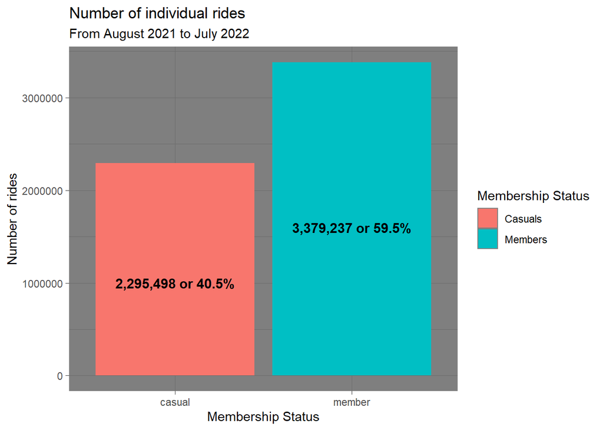

```r
year_summary %>%
  ggplot() +
    geom_col(mapping = aes(x = member_casual, y = number_of_rides, fill = member_casual)) +
    labs(title = "Number of individual rides", subtitle = "From August 2021 to July 2022", fill = "Membership Status") +
    annotate("text", x = 1, y = 1000000, label = "2,295,498 or 40.5%", fontface = "bold", size = 4) +
    annotate("text", x = 2, y = 1600000, label = "3,379,237 or 59.5%", fontface = "bold", size = 4) +
    xlab("Membership Status") +
    ylab("Number of rides") +
    scale_fill_discrete(labels = c("Casuals", "Members")) +
    theme_dark()
```

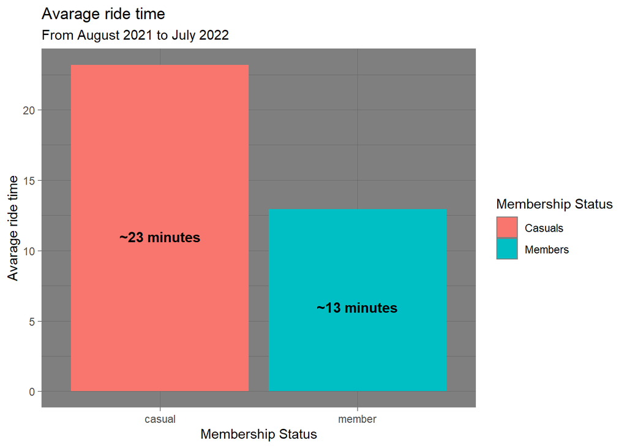

```r
year_summary %>%
  ggplot() +
    geom_col(mapping = aes(x = member_casual, y = avg_ride_time, fill = member_casual)) +
    labs(title = "Avarage ride time", subtitle = "From August 2021 to July 2022", fill = "Membership Status") +
    annotate("text", x = 1, y = 11, label = "~23 minutes", fontface = "bold", size = 4) +
    annotate("text", x = 2, y = 6, label = "~13 minutes", fontface = "bold", size = 4) +
    xlab("Membership Status") +
    ylab("Avarage ride time") +
    scale_fill_discrete(labels = c("Casuals", "Members")) +
    theme_dark()
```

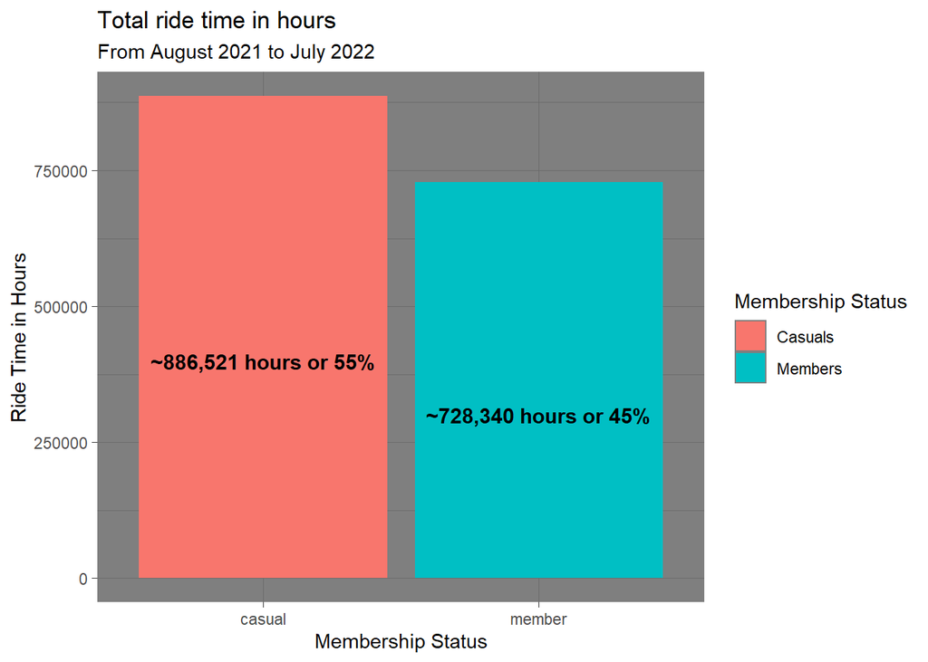

```r
year_summary %>%
  ggplot() +
    geom_col(mapping = aes(x = member_casual, y = total_ride_time_hours, fill = member_casual)) +
    labs(title = "Total ride time in hours", subtitle = "From August 2021 to July 2022", fill = "Membership Status") +
    annotate("text", x = 1, y = 400000, label = "~886,521 hours or 55%", fontface = "bold", size = 4) +
    annotate("text", x = 2, y = 300000, label = "~728,340 hours or 45%", fontface = "bold", size = 4) +
    xlab("Membership Status") +
    ylab("Ride Time in Hours") +
    scale_fill_discrete(labels = c("Casuals", "Members")) +
    theme_dark()
```

The next chunk creates a weekday table for us to visualize:

```r
## The first part of the code is just to create a Number of Rides per day of the Week table
casuals2 = filter(casuals, rideable_type != "docked_bike")
m_weekday = data.frame(table(members$weekday))
c_weekday = data.frame(table(casuals2$weekday))

## Bind them
weekdays_long = bind_cols(m_weekday, c_weekday)
```

```r
## delete the repeated column
weekdays_long = weekdays_long %>%
  select(-Var1...3)

## Rename the columns
weekdays_long = weekdays_long %>% rename_at(1, ~'weekday')
weekdays_long = weekdays_long %>% rename_at(2, ~'member_rides')
weekdays_long = weekdays_long %>% rename_at(3, ~'casual_rides')

## Reorganize the columns (this turned out to be useless and I had to sort it again inside the plot)
weekdays_long = weekdays_long %>% arrange(factor(weekday, levels = c("Monday", "Tuesday", "Wednesday", "Thursday", "Friday", "Saturday", "Sunday")))

## Melt them so we can plot both members and casuals side by side
library(reshape2)
weekdays_final = melt(weekdays_long, id.vars = "weekday")
weekdays_final  %>%  rename_at(2, ~"membership_status")
```

```
##          weekday membership_status  value
## 1        domingo      member_rides 417978
## 2   quarta-feira      member_rides 522648
## 3   quinta-feira      member_rides 522662
## 4         sábado      member_rides 453490
## 5  segunda-feira      member_rides 472392
## 6    sexta-feira      member_rides 466680
## 7    terça-feira      member_rides 523387
## 8        domingo      casual_rides 424003
## 9   quarta-feira      casual_rides 261770
## 10  quinta-feira      casual_rides 293174
## 11        sábado      casual_rides 472663
## 12 segunda-feira      casual_rides 271728
## 13   sexta-feira      casual_rides 318914
## 14   terça-feira      casual_rides 253246
```

Now we can visualize it:

[figure not shown]

```r
weekdays_final %>%
  ggplot(aes(x = factor(weekday, levels = c("Monday", "Tuesday", "Wednesday", "Thursday", "Friday", "Saturday", "Sunday")), y = value, fill = factor(variable, levels = c("casual_rides", "member_rides")))) +
    geom_bar(stat='identity', position='dodge') +
    labs(title = "Number of rides by day of the week", subtitle = "From August 2021 to July 2022", fill = "Membership Status") +
    annotate("text", x = 2, y = 400000, label = "Members preferred day: \nTuesday: 523,387 rides", fontface = "bold", size = 4) +
    annotate("text", x = 6, y = 400000, label = "Casuals preferred day: \nSaturday: 472,663 rides", fontface = "bold", size = 4) +
    xlab("Days of the Week") +
    ylab("Number of Rides") +
    scale_fill_discrete(labels = c("Casuals", "Members")) +
    theme_dark()
```

Last but not least we visualize the number of rides per season. And yeah, we’ll manipulate the seasons_summary data frame before we do visualize it…

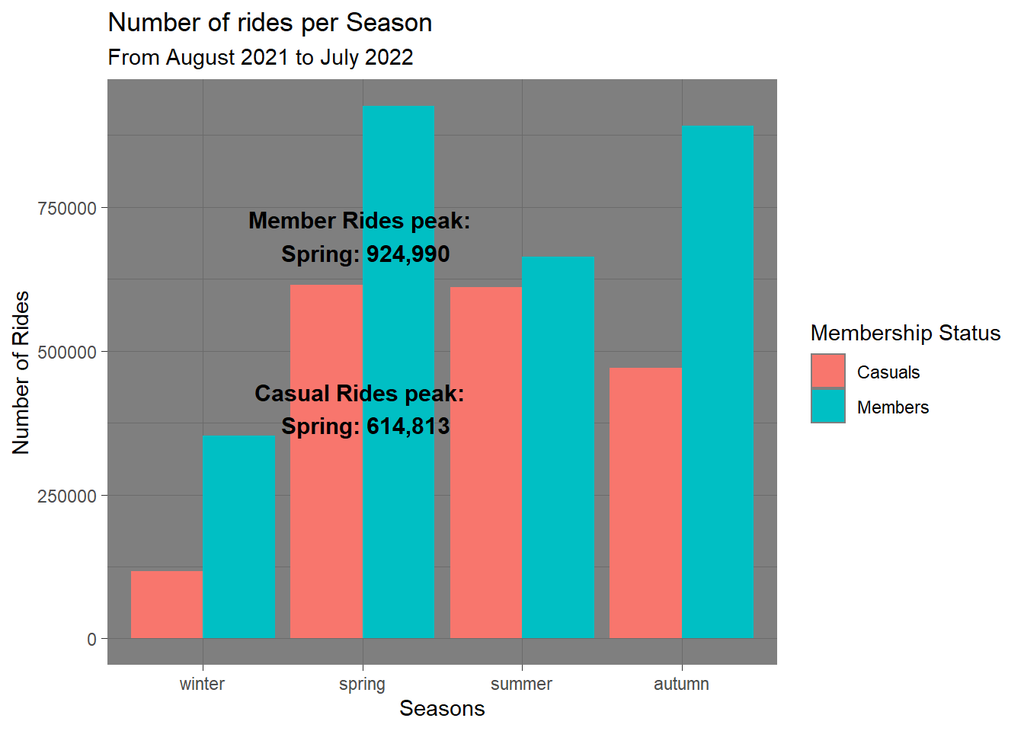

```r
seasons_summary$number_of_rides = as.numeric(as.character(seasons_summary$number_of_rides))
seasons_summary %>%
  rename_at(2, ~'Membership_Status') %>%
  ggplot(aes(x = factor(season, levels = c("winter", "spring", "summer", "autumn")), y = number_of_rides, fill = Membership_Status)) +
    geom_bar(stat='identity', position='dodge') +
    labs(title = "Number of rides per Season", subtitle = "From August 2021 to July 2022", fill = "Membership Status") +
    annotate("text", x = 2, y = 700000, label = "Member Rides peak: \n Spring: 924,990", fontface = "bold", size = 4) +
    annotate("text", x = 2, y = 400000, label = "Casual Rides peak: \n Spring: 614,813", fontface = "bold", size = 4) +
    xlab("Seasons") +
    ylab("Number of Rides") +
    scale_fill_discrete(labels = c("Casuals", "Members")) +
    theme_dark()
```

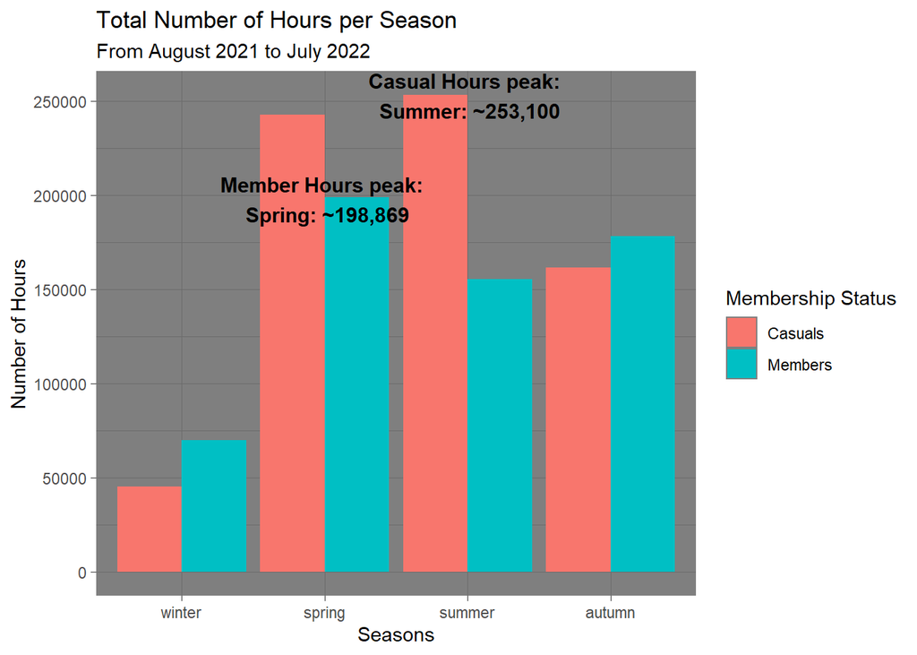

```r
seasons_summary %>%
  rename_at(2, ~'Membership_Status') %>%
  ggplot(aes(x = factor(season, levels = c("winter", "spring", "summer", "autumn")), y = total_ride_time_hours, fill = Membership_Status)) +
    geom_bar(stat='identity', position='dodge') +
    labs(title = "Total Number of Hours per Season", subtitle = "From August 2021 to July 2022", fill = "Membership Status") +
    annotate("text", x = 2, y = 198000, label = "Member Hours peak: \n Spring: ~198,869", fontface = "bold", size = 4) +
    annotate("text", x = 3, y = 253100, label = "Casual Hours peak: \n Summer: ~253,100", fontface = "bold", size = 4) +
    xlab("Seasons") +
    ylab("Number of Hours") +
    scale_fill_discrete(labels = c("Casuals", "Members")) +
    theme_dark()
```

```r
## first we create seasons data frame for each category
seasons_members = rbind(winter_members, spring_members, summer_members, autumn_members)
seasons_casuals = rbind(winter_casuals2, spring_casuals2, summer_casuals2, autumn_casuals2)

## then we count the number of rides total, because the time period doesn't line exactly with the previous total that we have for the last 12 months
seasons_members %>%
  summarise(total_rides = sum(number_of_rides))
```

```
## # A tibble: 1 × 1
##   total_rides
##         <int>
## 1     2833163
```